# Lecture_7_Week3

Thrisha Rajkumar

2024-10-16

### load packages: the Palmer penguins data set & tidyverse

First, load tidyverse

```r
library(tidyverse)
```

Second, we will be based on the Palmer penguins data set, so load the dataset

```r
library(palmerpenguins)
head(penguins)
```

| species | island | bill_length_mm | bill_depth_mm | flipper_length_mm | body_mass_g | sex | year |
| --- | --- | --- | --- | --- | --- | --- | --- |
| Adelie | Torgersen | 39.1 | 18.7 | 181 | 3750 | male | 2007 |
| Adelie | Torgersen | 39.5 | 17.4 | 186 | 3800 | female | 2007 |
| Adelie | Torgersen | 40.3 | 18.0 | 195 | 3250 | female | 2007 |
| Adelie | Torgersen | NA | NA | NA | NA | NA | 2007 |
| Adelie | Torgersen | 36.7 | 19.3 | 193 | 3450 | female | 2007 |
| Adelie | Torgersen | 39.3 | 20.6 | 190 | 3650 | male | 2007 |

We also need the ggplot2 package, which is contained in tidyverse. The ggplot2 package implements Leland Wilkinson’s Grammar of Graphics: 1. An aesthetic is a mapping between a variable and a visual cue. 2. A glyph is a basic graphical element e.g. a mark or symbol. 3. A guide is an annotation which provides context.

### Univariate plot - histogram

First, we create a plot object using the ggplot function. The plot object specifies the aesthetic (using the aes() function).

A histogram plot with an aesthetic that maps Flipper length to horizontal position. Using the geom_histogram function to plot histogram

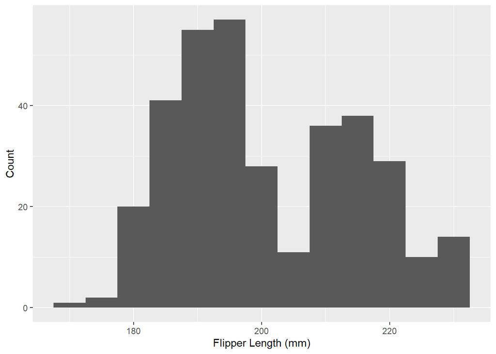

```r
univar_plot <- ggplot(data=penguins, aes(x=flipper_length_mm)) + xlab("Flipper Length (mm)")
univar_plot+geom_histogram(binwidth = 5)+ylab("Count")
```

Note that we have created guides using xlab & ylabels;

### Univariate plot - density plot

Replacing the above geom_histogram with geom_density to plot density:

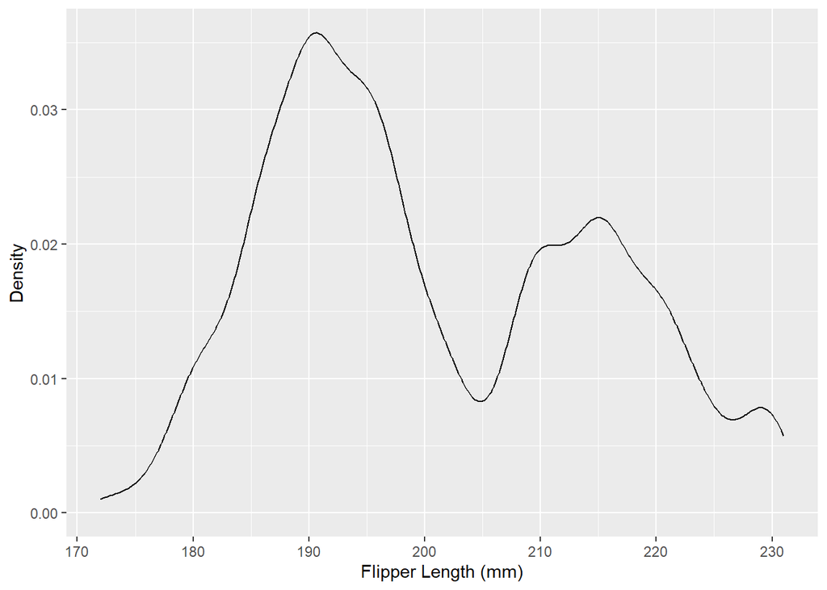

```r
univar_plot+geom_density(adjust=0.5)+ylab('Density')
```

### Bivariate plots - density

Adding another aesthetic that maps species to color, and use geom_density in a simlar way to the above density plot:

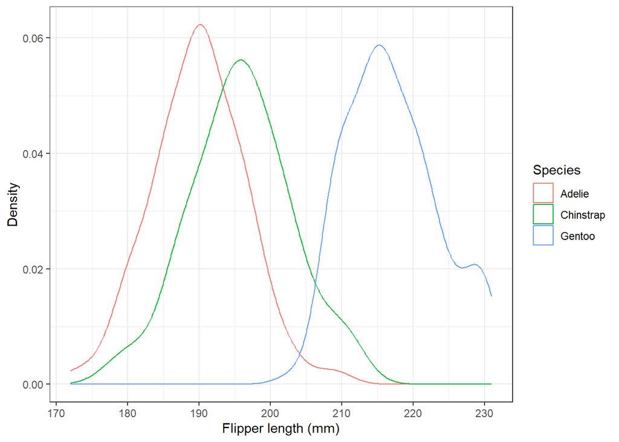

```r
ggplot(data=rename(penguins, Species=species), aes(x=flipper_length_mm, color=Species))+
  geom_density()+theme_bw()+xlab("Flipper length (mm)")+ylab("Density")
```

### Bivariate plots - box

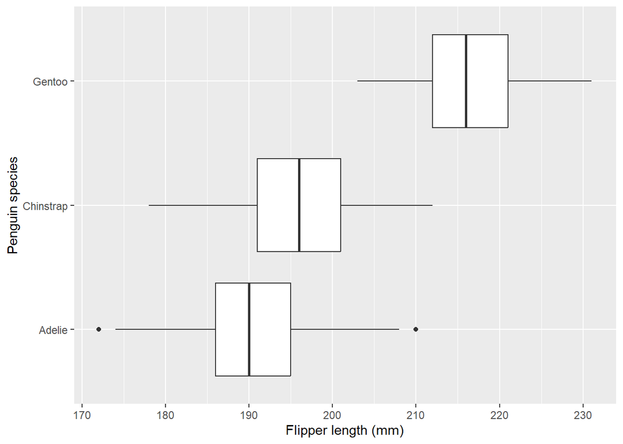

```r
ggplot(data=penguins, aes(x=flipper_length_mm, y=species))+geom_boxplot()+
  xlab('Flipper length (mm)') + ylab("Penguin species")
```

### Bivariate plots - violin

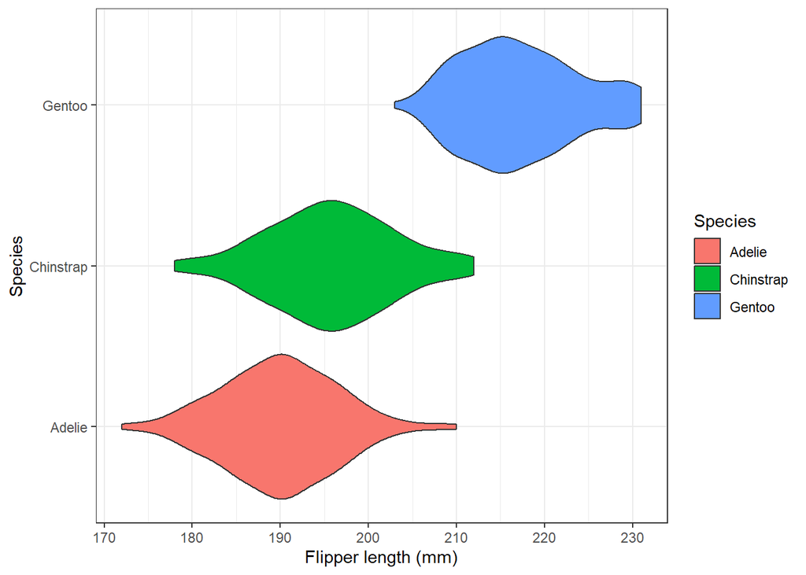

```r
ggplot(data=rename(penguins, Species=species), aes(x=flipper_length_mm, y=Species, fill=Species))+geom_violin()+theme_bw()+xlab("Flipper length (mm)")
```

### Bivariate plots - scatter

Scatter plot for flipper length vs body mass, using geom_point:

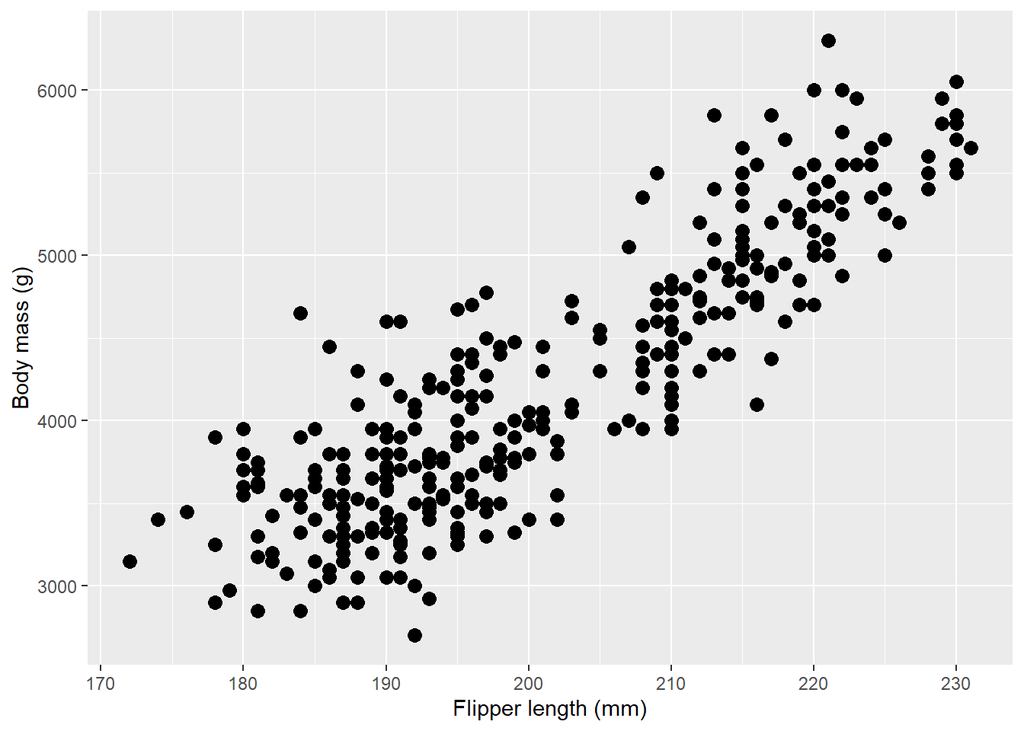

```r
mass_flipper_scatter <- ggplot(data=penguins, aes(y=body_mass_g, x=flipper_length_mm))+
  xlab("Flipper length (mm)") + ylab("Body mass (g)")
mass_flipper_scatter+geom_point(size=3)
```

### Adding more aesthetics

Adding another aesthetic using arguments in the geom_point function (Bill length to color):

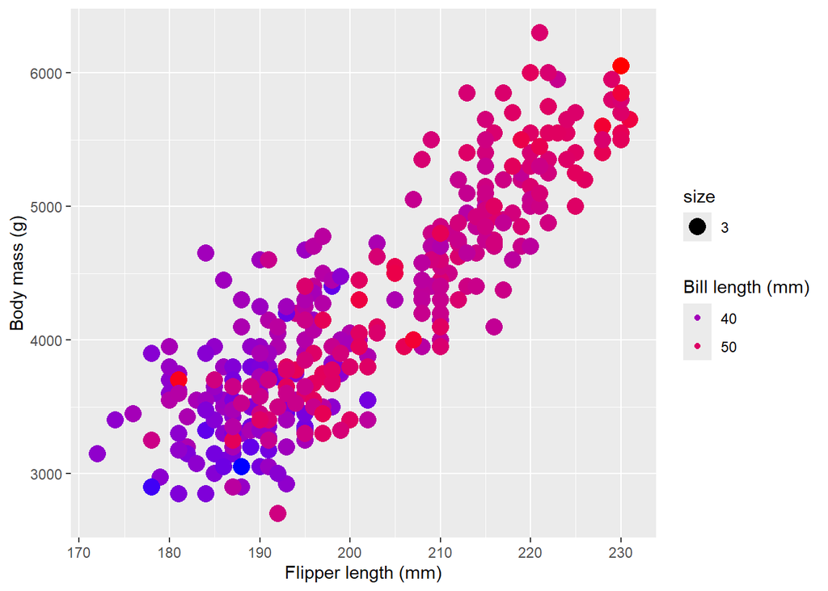

```r
mass_flipper_scatter+geom_point(aes(color=bill_length_mm, size=3))+
  scale_color_gradient(low="blue", high="red")+guides(color=guide_legend("Bill length (mm)"))
```

Adding one more aesthetic (Bill depth to size):

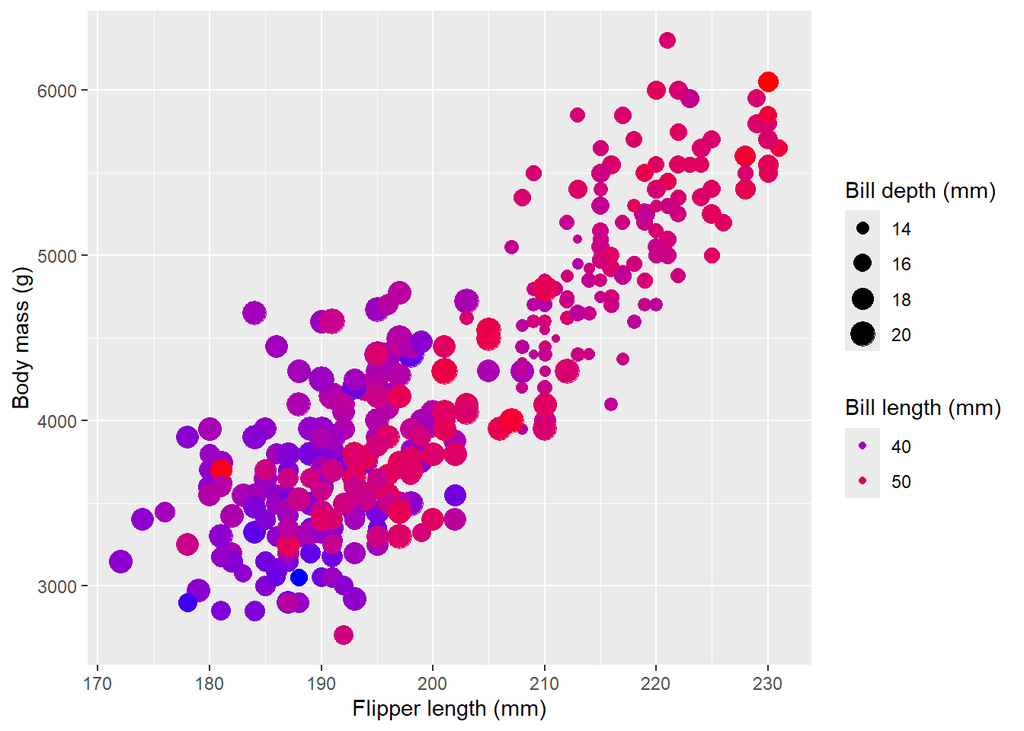

```r
mass_flipper_scatter+geom_point(aes(color=bill_length_mm, size=bill_depth_mm))+
  scale_color_gradient(low="blue", high="red")+
  guides(color=guide_legend("Bill length (mm)"), size=guide_legend("Bill depth (mm)"))
```

### Multivariate plots

Changing two of the aesthetic, one which maps species to color, another one with map species to shape:

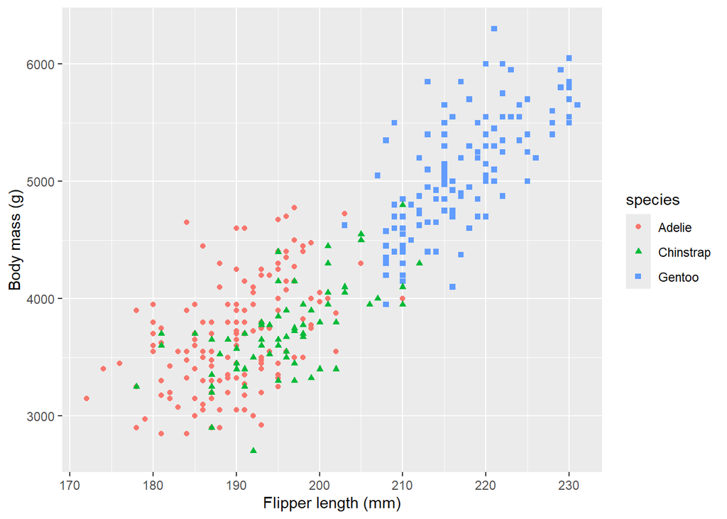

```r
mass_flipper_scatter+geom_point(aes(color=species, shape=species))
```

One can also map species to text:

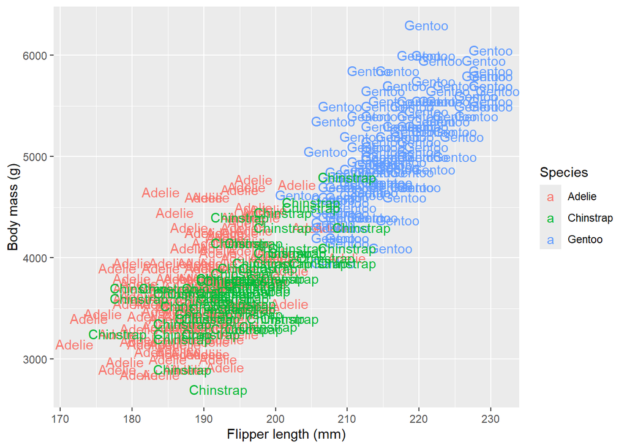

```r
mass_flipper_scatter + geom_text(aes(label=species, color=species)) +
  guides(color=guide_legend("Species"))
```

Alternatively, one can use facets to display a categorical variable (species):

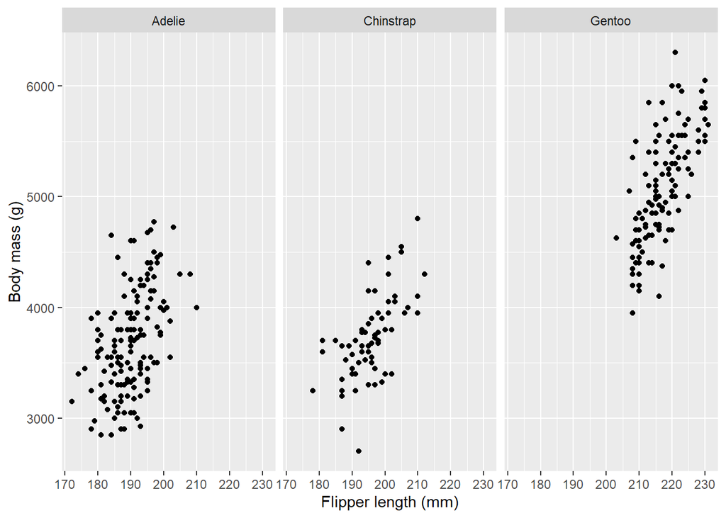

```r
mass_flipper_scatter + geom_point() + facet_wrap(~species)
```